# Aula 4 - RMarkdown

6 de Janeiro de 2017

## Geração de relatórios com RMarkdown - Aula 4

## O que é? E por que usar?

- O markdown é uma linguagem de marcação para geração de documentos
- Os desenvolvedores do RStudio, criaram uma versão integrada, chamada RMarkdown
- 99% do que funciona com Markdown, funciona com o RMarkdown, mas tem aquele 1%….
- Com o RMarkdown podemos gerar:
  - Apresentações
  - Word
  - PDF (para artigos, recomendo o uso do Knitr, com LaTeX)
  - HTML
- Facilidade com versionamento de código (espero abordar em cursos futuros)

## Criando um arquivo de exemplo

- No RStudio, selecionem:
  - File -> New File -> R Markdown
  - Coloquem um título
  - Vamos deixar marcado a opção HTML
  - Cliquem em OK
- Compilando o arquivo com ctrl+shift+k (ou botão Knit)
- Gerando PDF e Word

## Cuidados ao colocar código

- Por ser uma linguagem bastante genérica, nem todas as funcionalidades de um tipo de documento, pode funcionar em outro
- Por exemplo, se introduzirmos código \(LaTeX\) dentro do documento, ele será compilado em PDF normalmente, mas apresentará problemas de exibição em HTML ou Word
- Portanto, devemos definir PARA QUE queremos gerar o nosso documento:
  - Artigo -> PDF
  - Apresentação -> HTML/PDF
  - Página WEB -> HTML
  - Perder tempo -> DOC

## Entendendo a estrutura do documento

- Cabeçalho metada YAML
- Markdown
- Pedaços (chunks) de código R

## Markdown

- Vamos ver as opções do Markdown, utilizando a própria referência que vem com o RStudio
- HELP -> Cheatsheets -> R Markdown Reference Guide
- Formatação de texto:
  - Itálico: **italico**
  - Negrito: ****negrito****
  - Sobrescrito: 2^2^ => 2<sup>2</sup>
  - Tachado: ~~tachado~~

## Capítulos e seções

- # Capítulo (equivalente ao h1 em html)
- ## Seção (equivalente ao h2 em html)
- ### Sub-seção (equivalente ao h3 em html)
- O Markdown aceita até 6 níveis de formatação

## Quebra de linha

- O Markdown não quebra a linha como está no editor, a quebra é feita de forma automática
  - WYSIWYG x WYMIWYG
- Ou, devemos deixar 2 ou mais espaços entre as linhas para mostrar que queremos quebrar a linha.

## Listas

- Podemos criar listas com os comandos:
- +
- -
- 1. (lista numerada)
- Ex:  
  - Item 1  
  + Item 1a  
  * Item 2
- Cuidado, items e subitens são diferenciados pela identação (coloquem o Item 1a, como subitem do Item 1)

## Outros elementos de formatação

- Imagem: ![](caminho.png)
- Para definirmos o tamanho das imagens, há vários métodos
  - Em HTML, podemos trabalhar com css ou
  - Colocar a tag <img style="width:100px,height:100px" src="imagem.jpg">
  - Em \(LaTeX\) podemos inserir a imagem com o comando \includegraphics e especificar o tamanho
- Equação inline:
  - $y = \beta_{0} + \beta_{1}x_{0}+\beta_{2}x_{1}$
  - \(y = \beta_{0} + \beta_{1}x_{0}+\beta_{2}x_{1}\)
  - Para outros símbolos matemáticos:  
    +https://www.mathjax.org/ se o documento for html  
    +http://tug.ctan.org/info/symbols/comprehensive/symbols-a4.pdf se for pdf

## Blocos de texto

- Podemos criar blocos de citação com >

> O tambor faz muito barulho  
> mas é vazio por dentro  
> (Barão de Itararé)
- Também podemos colocar código no meio de nosso texto com ```

> ```  
> x = rnorm(10)  
> ```

```
x = rnorm(10)
```

- Daqui a pouco veremos como executar esse código

## Tabelas

- Podemos fazer a criação manual de nossas tabelas com:  
  Cabeçalho 1 | Cabeçalho 2  
  ———–|———— 1 | 2  
  3 | 4

| Cabeçalho 1 | Cabeçalho 2 |
| --- | --- |
| 1 | 2 |
| 3 | 4 |

- A formatação da tabela deve ser feita através de CSS
- Existem outros pacotes que torna muito mais fácil a criação de tabelas

## Pander

- Um dos pacotes mais práticos que encontrei é o pander
- Vamos recuperar os dados da tabela cidade_sintese

```r
  conCurso <- dbConnect(PostgreSQL(), user= "r_workflow", password="curso",
                        dbname="r_workflow",host="143.107.205.218",port='5432')
  sSql <- "select * from s3672792.cidade_sintese"
  res <- dbSendQuery(conCurso, sSql)
  dCidade <- fetch(res,n=-1)
```

## Pander

- Vamos plotar uma tabela com o codigo do município e seu nome

```r
  library('pander')
  dTemp <- head(dCidade[,c('codmun','nome')])
  pander(dTemp)
```

| codmun | nome |
| --- | --- |
| 312950 | IBIA/MG |
| 314015 | MARIO CAMPOS/MG |
| 355520 | TURIUBA/SP |
| 170030 | AGUIARNOPOLIS/TO |
| 410785 | FLOR DA SERRA DO SUL/PR |
| 420435 | CORDILHEIRA ALTA/SC |

## Pander

- Podemos mudar o alinhamento com o comando justify

```r
  pander(dTemp,justify=c('center','left') )
```

| codmun | nome |
| --- | --- |
| 312950 | IBIA/MG |
| 314015 | MARIO CAMPOS/MG |
| 355520 | TURIUBA/SP |
| 170030 | AGUIARNOPOLIS/TO |
| 410785 | FLOR DA SERRA DO SUL/PR |
| 420435 | CORDILHEIRA ALTA/SC |

## Pander

- Para renomear as colunas, basta renomear o dataframe
- Também podemos colocar um título em nossa tabela

```r
  names(dTemp) <- c('Cód. IBGE','Nome')
  pander(dTemp,justify=c('center','left'),caption='Municípios' )
```

Municípios

| Cód. IBGE | Nome |
| --- | --- |
| 312950 | IBIA/MG |
| 314015 | MARIO CAMPOS/MG |
| 355520 | TURIUBA/SP |
| 170030 | AGUIARNOPOLIS/TO |
| 410785 | FLOR DA SERRA DO SUL/PR |
| 420435 | CORDILHEIRA ALTA/SC |

## Pander

- Outras funcionalidades do Pander:
  - http://rapporter.github.io/pander/
- Para quem for trabalhar com \(LaTeX\) recomendo utilizar a função xtable, com only.contents=TRUE
  - \begin{tabular}
  - print(xtable(dTemp),only.contents=TRUE)
  - \end{tabular}
- Da mesma forma, quem for trabalhar com tabelas dinâmicas (sem saber a formatação prévia), recomendo utilizar o pacote longtabu do \(LaTeX\)

## Inserindo comandos de R

- Para inserirmos comandos de R, basta criarmos um chunk de código, especificando a linguagem (no caso, R)

> ```{r}  
> x = rnorm(10)  
> x  
> ```

```
##  [1]  0.41762575 -1.15093624  1.71654945  0.47208403 -0.01983988
##  [6]  1.41612273 -0.15686333 -1.74884201 -1.31609843  0.32653492
```

## Principais parâmetros do chunk de código

- Podemos passar alguns parâmetros úteis nos chunks:
  - eval: se FALSE, o knitr não avaliará o chunk
  - include: se FALSE, executa o chunk, mas não coloca no documento final
  - echo: se FALSE, não exibe o código, apenas o resultado final
  - results: se 'asis', exibe o código sem formatação de markup (por exemplo, quando queremos retornar um código de tabela em \(LaTeX\))
  - error,message,warning: se FALSE, não exibe erros, mensagens ou avisos ao executar o código
  - cache: se TRUE, o chunk não será recompilado, até ser alterado

## Principais parâmetros do chunk de código

- Opções para figuras:
  - fig.align: 'left','right','center','default'
  - fig.cap: Título da imagem, em \(LaTeX\)
  - fig.lp: prefixo do label da imagem em \(LaTeX\)
  - fig.width: largura da imagem
  - fig.height: altura da imagem

## Plotando gráficos com R

- Para plotarmos os gráficos em nossos documentos, basta chamar a função plot ou ggplot dentro do chunk de código

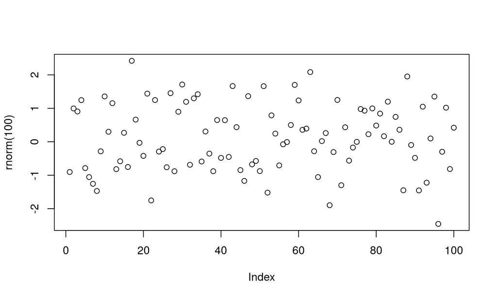

```r
  plot(rnorm(100))
```

## Outras linguagens aceitas pelo RMarkdown

- Podemos criar chunks com:
  - Python
  - **SQL**
  - Bash
  - Rcpp
  - Stan
  - Javascript
  - Css

## Exemplo com SQL

> ```{sql, connection=conCurso}  
> select * from s3672792.cidade_sintese  
> ```

Displaying records 1 - 10

| codmun | nome | estado | pop_alfabetizada | pop_matriculada_em_2015 | pop_homens | pop_mulheres | nro_estab_sus |
| --- | --- | --- | --- | --- | --- | --- | --- |
| 312950 | IBIA/MG | MG | 20228 | 642 | 11858 | 11360 | 11 |
| 314015 | MARIO CAMPOS/MG | MG | 11103 | 512 | 6641 | 6551 | 2 |
| 355520 | TURIUBA/SP | SP | 1610 | 61 | 997 | 933 | 1 |
| 170030 | AGUIARNOPOLIS/TO | TO | 3699 | 226 | 2618 | 2544 | 1 |
| 410785 | FLOR DA SERRA DO SUL/PR | PR | 3971 | 238 | 2398 | 2328 | 7 |
| 420435 | CORDILHEIRA ALTA/SC | SC | 3386 | 279 | 1921 | 1846 | 2 |
| 352240 | ITAPEVA/SP | SP | 75190 | 4284 | 43243 | 44510 | 37 |
| 251180 | PIRPIRITUBA/PB | PB | 6743 | 212 | 5114 | 5212 | 6 |
| 291020 | DOM MACEDO COSTA/BA | BA | 2899 | 125 | 1897 | 1977 | 3 |
| 521030 | ISRAELANDIA/GO | GO | 2408 | 94 | 1463 | 1424 | 3 |

## Exemplo com SQL

- Por padrão o comando exibe os 10 primeiros resultados em tela
  - Podemos alterar isso com o max.print: ```{sql, connection=conCurso, max.print = 20}
  - max.print = -1 é ilimitado
- Para alterar o caption:
  - tab.cap = 'Título da tabela
  - tab.cap = NA - para ficar sem título
- Para armazenar o resultado em um dataframe
  - output.var="dCidade"
  - Ao usar output.var, o resultado não é impresso no documento
- Para usar variáveis do R, utilize a sintaxe **?**
  - select * from s3672792.sintese_cidades where codmun = ?iCodMun

## Últimas considerações

- Para atribuir uma conexão padrão:
  - knitr::opts_chunk$set(connection = "conCurso")
- Apesar de ser possível, previsa utilizar o comando css no header YAML

## Geração de páginas com Shiny

## O que é o Shiny?

- O Shiny (https://shiny.rstudio.com/) é um framework de desenvolvimento WEB com R
- A documentação na página é MUITO BOA, recomendo
- Você pode utilizar a galeria para se inspirar
- Você pode criar páginas, sem saber (quase) nada de HTML

## Criando uma página com Shiny

- Existem 2 modos principais de se criar uma aplicação com Shiny
  - 2 arquivos: ui.R e server.R
  - 1 arquivo: app.R (mais fácil de manter, na minha opinião)
- Vamos criar nosso primeiro aplicativo com Shiny:
  - File -> New File -> Shiny Web App
  - Dêem um nome para sua aplicação
  - Escolham Single file app
  - Escolham um lugar para salvar
- No arquivo app.R que foi criado, cliquem em Run App

## Estrutura e organização do arquivo

- Parte UI (User Interface)
  - Fluidpage
  - titlePanel
  - sidebarLayout
  - sidebarPanel
  - sliderInput
  - mainPanel
  - plotOutput

## Estrutura e organização do arquivo

- Parte Server
  - input e output
  - renderPlot

## Executando a aplicação

- shinyApp
  - shiny::runApp(display.mode="showcase")
- Start simple: vamos dar uma olhada nas funcionalidades de algumas aplicações na galeria do Shiny
  - Kmeans example
  - Word cloud
  - DataTables Demo
  - Widget Gallery

## Criando uma página de exemplo

- Vamos recuperar os dados da tabela cidade_sintese

```r
  conCurso <<- dbConnect(PostgreSQL(), user= "r_workflow", password="curso", dbname="r_workflow",host="143.107.205.218",port='5432')
  sSql <- "select * from s3672792.cidade_sintese"
  res <- dbSendQuery(conCurso, sSql)
  dCidade <- fetch(res,n=-1)
```

- O objeto é, ao digitar o nome de uma cidade, fazer a busca e retornar os dados da mesma
  - Scripts/shiny/Cidades

## Plotando um mapa interativo com Shiny

```
- Scripts/shiny/Mapa
```